# Lab 2: Spatial Analysis and Visualization

Healthcare Access and Equity in Pennsylvania

Author

Maude Ceruso

Published

February 23, 2026

## Assignment Overview

**Learning Objectives:** - Apply spatial operations to answer policy-relevant research questions - Integrate census demographic data with spatial analysis - Create publication-quality visualizations and maps - Work with spatial data from multiple sources - Communicate findings effectively for policy audiences

## Part 1: Healthcare Access for Vulnerable Populations

### Research Question

**Which Pennsylvania counties have the highest proportion of vulnerable populations (elderly + low-income) living far from hospitals?**

Your analysis should identify counties that should be priorities for healthcare investment and policy intervention.

### Required Analysis Steps

Complete the following analysis, documenting each step with code and brief explanations:

#### Step 1: Data Collection (5 points)

Load the required spatial data: - Pennsylvania county boundaries - Pennsylvania hospitals (from lecture data) - Pennsylvania census tracts

**Your Task:**

```r
# Load spatial data
pa_counties <- st_read("data/Pennsylvania_County_Boundaries.shp")
hospitals <- st_read("data/hospitals.geojson")
hospitals <- hospitals %>%
  st_transform(st_crs(pa_counties))

census_tracts <- tracts(state = "PA", cb = TRUE)
census_tracts <- census_tracts %>%
  st_transform(st_crs(pa_counties))

# Check that all data loaded correctly
glimpse(pa_counties)
```

```
Rows: 67
Columns: 20
$ OBJECTID   <int> 336, 337, 338, 339, 340, 341, 342, 343, 344, 345, 346, 347,…
$ MSLINK     <int> 46, 8, 9, 58, 59, 60, 62, 63, 42, 43, 44, 47, 48, 49, 50, 5…
$ COUNTY_NAM <chr> "MONTGOMERY", "BRADFORD", "BUCKS", "TIOGA", "UNION", "VENAN…
$ COUNTY_NUM <chr> "46", "08", "09", "58", "59", "60", "62", "63", "42", "43",…
$ FIPS_COUNT <chr> "091", "015", "017", "117", "119", "121", "125", "127", "08…
$ COUNTY_ARE <chr> NA, NA, NA, NA, NA, NA, NA, NA, NA, NA, NA, NA, NA, NA, NA,…
$ COUNTY_PER <chr> NA, NA, NA, NA, NA, NA, NA, NA, NA, NA, NA, NA, NA, NA, NA,…
$ NUMERIC_LA <int> 5, 2, 5, 2, 2, 3, 1, 2, 1, 3, 1, 2, 2, 2, 2, 2, 2, 2, 2, 1,…
$ COUNTY_N_1 <int> 46, 8, 9, 58, 59, 60, 62, 63, 42, 43, 44, 47, 48, 49, 50, 5…
$ AREA_SQ_MI <dbl> 487.4271, 1161.3379, 622.0836, 1137.2480, 319.1893, 683.367…
$ SOUND      <chr> NA, NA, NA, NA, NA, NA, NA, NA, NA, NA, NA, NA, NA, NA, NA,…
$ SPREAD_SHE <chr> NA, NA, NA, NA, NA, NA, NA, NA, NA, NA, NA, NA, NA, NA, NA,…
$ IMAGE_NAME <chr> "poll.bmp", "poll.bmp", "poll.bmp", "poll.bmp", "poll.bmp",…
$ NOTE_FILE  <chr> NA, NA, NA, NA, NA, NA, NA, NA, NA, NA, NA, NA, NA, NA, NA,…
$ VIDEO      <chr> NA, NA, NA, NA, NA, NA, NA, NA, NA, NA, NA, NA, NA, NA, NA,…
$ DISTRICT_N <chr> "06", "03", "06", "03", "03", "01", "12", "04", "02", "01",…
$ PA_CTY_COD <chr> "46", "08", "09", "59", "60", "61", "63", "64", "42", "43",…
$ MAINT_CTY_ <chr> "4", "9", "1", "7", "8", "5", "4", "6", "5", "4", "7", "3",…
$ DISTRICT_O <chr> "6-4", "3-9", "6-1", "3-7", "3-8", "1-5", "12-4", "4-6", "2…
$ geometry   <MULTIPOLYGON [m]> MULTIPOLYGON (((-8398884 48..., MULTIPOLYGON (…
```

```r
st_crs(pa_counties)
```

```
Coordinate Reference System:
  User input: WGS 84 / Pseudo-Mercator
  wkt:
PROJCRS["WGS 84 / Pseudo-Mercator",
    BASEGEOGCRS["WGS 84",
        ENSEMBLE["World Geodetic System 1984 ensemble",
            MEMBER["World Geodetic System 1984 (Transit)"],
            MEMBER["World Geodetic System 1984 (G730)"],
            MEMBER["World Geodetic System 1984 (G873)"],
            MEMBER["World Geodetic System 1984 (G1150)"],
            MEMBER["World Geodetic System 1984 (G1674)"],
            MEMBER["World Geodetic System 1984 (G1762)"],
            MEMBER["World Geodetic System 1984 (G2139)"],
            MEMBER["World Geodetic System 1984 (G2296)"],
            ELLIPSOID["WGS 84",6378137,298.257223563,
                LENGTHUNIT["metre",1]],
            ENSEMBLEACCURACY[2.0]],
        PRIMEM["Greenwich",0,
            ANGLEUNIT["degree",0.0174532925199433]],
        ID["EPSG",4326]],
    CONVERSION["Popular Visualisation Pseudo-Mercator",
        METHOD["Popular Visualisation Pseudo Mercator",
            ID["EPSG",1024]],
        PARAMETER["Latitude of natural origin",0,
            ANGLEUNIT["degree",0.0174532925199433],
            ID["EPSG",8801]],
        PARAMETER["Longitude of natural origin",0,
            ANGLEUNIT["degree",0.0174532925199433],
            ID["EPSG",8802]],
        PARAMETER["False easting",0,
            LENGTHUNIT["metre",1],
            ID["EPSG",8806]],
        PARAMETER["False northing",0,
            LENGTHUNIT["metre",1],
            ID["EPSG",8807]]],
    CS[Cartesian,2],
        AXIS["easting (X)",east,
            ORDER[1],
            LENGTHUNIT["metre",1]],
        AXIS["northing (Y)",north,
            ORDER[2],
            LENGTHUNIT["metre",1]],
    USAGE[
        SCOPE["Web mapping and visualisation."],
        AREA["World between 85.06°S and 85.06°N."],
        BBOX[-85.06,-180,85.06,180]],
    ID["EPSG",3857]]
```

```r
st_geometry(pa_counties)
```

```
Geometry set for 67 features
Geometry type: MULTIPOLYGON
Dimension:     XY
Bounding box:  xmin: -8963377 ymin: 4825316 xmax: -8314404 ymax: 5201413
Projected CRS: WGS 84 / Pseudo-Mercator
First 5 geometries:
```

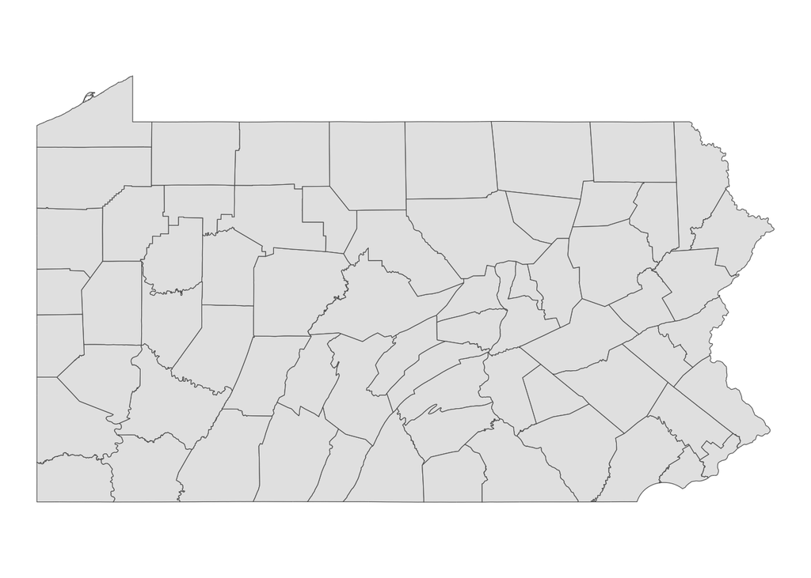

```r
  # plot with ggplot2
ggplot(pa_counties) +
  geom_sf() +
  theme_void()
```

```r
st_crs(hospitals)
```

```
Coordinate Reference System:
  User input: WGS 84 / Pseudo-Mercator
  wkt:
PROJCRS["WGS 84 / Pseudo-Mercator",
    BASEGEOGCRS["WGS 84",
        ENSEMBLE["World Geodetic System 1984 ensemble",
            MEMBER["World Geodetic System 1984 (Transit)"],
            MEMBER["World Geodetic System 1984 (G730)"],
            MEMBER["World Geodetic System 1984 (G873)"],
            MEMBER["World Geodetic System 1984 (G1150)"],
            MEMBER["World Geodetic System 1984 (G1674)"],
            MEMBER["World Geodetic System 1984 (G1762)"],
            MEMBER["World Geodetic System 1984 (G2139)"],
            MEMBER["World Geodetic System 1984 (G2296)"],
            ELLIPSOID["WGS 84",6378137,298.257223563,
                LENGTHUNIT["metre",1]],
            ENSEMBLEACCURACY[2.0]],
        PRIMEM["Greenwich",0,
            ANGLEUNIT["degree",0.0174532925199433]],
        ID["EPSG",4326]],
    CONVERSION["Popular Visualisation Pseudo-Mercator",
        METHOD["Popular Visualisation Pseudo Mercator",
            ID["EPSG",1024]],
        PARAMETER["Latitude of natural origin",0,
            ANGLEUNIT["degree",0.0174532925199433],
            ID["EPSG",8801]],
        PARAMETER["Longitude of natural origin",0,
            ANGLEUNIT["degree",0.0174532925199433],
            ID["EPSG",8802]],
        PARAMETER["False easting",0,
            LENGTHUNIT["metre",1],
            ID["EPSG",8806]],
        PARAMETER["False northing",0,
            LENGTHUNIT["metre",1],
            ID["EPSG",8807]]],
    CS[Cartesian,2],
        AXIS["easting (X)",east,
            ORDER[1],
            LENGTHUNIT["metre",1]],
        AXIS["northing (Y)",north,
            ORDER[2],
            LENGTHUNIT["metre",1]],
    USAGE[
        SCOPE["Web mapping and visualisation."],
        AREA["World between 85.06°S and 85.06°N."],
        BBOX[-85.06,-180,85.06,180]],
    ID["EPSG",3857]]
```

```r
st_crs(census_tracts)
```

```
Coordinate Reference System:
  User input: WGS 84 / Pseudo-Mercator
  wkt:
PROJCRS["WGS 84 / Pseudo-Mercator",
    BASEGEOGCRS["WGS 84",
        ENSEMBLE["World Geodetic System 1984 ensemble",
            MEMBER["World Geodetic System 1984 (Transit)"],
            MEMBER["World Geodetic System 1984 (G730)"],
            MEMBER["World Geodetic System 1984 (G873)"],
            MEMBER["World Geodetic System 1984 (G1150)"],
            MEMBER["World Geodetic System 1984 (G1674)"],
            MEMBER["World Geodetic System 1984 (G1762)"],
            MEMBER["World Geodetic System 1984 (G2139)"],
            MEMBER["World Geodetic System 1984 (G2296)"],
            ELLIPSOID["WGS 84",6378137,298.257223563,
                LENGTHUNIT["metre",1]],
            ENSEMBLEACCURACY[2.0]],
        PRIMEM["Greenwich",0,
            ANGLEUNIT["degree",0.0174532925199433]],
        ID["EPSG",4326]],
    CONVERSION["Popular Visualisation Pseudo-Mercator",
        METHOD["Popular Visualisation Pseudo Mercator",
            ID["EPSG",1024]],
        PARAMETER["Latitude of natural origin",0,
            ANGLEUNIT["degree",0.0174532925199433],
            ID["EPSG",8801]],
        PARAMETER["Longitude of natural origin",0,
            ANGLEUNIT["degree",0.0174532925199433],
            ID["EPSG",8802]],
        PARAMETER["False easting",0,
            LENGTHUNIT["metre",1],
            ID["EPSG",8806]],
        PARAMETER["False northing",0,
            LENGTHUNIT["metre",1],
            ID["EPSG",8807]]],
    CS[Cartesian,2],
        AXIS["easting (X)",east,
            ORDER[1],
            LENGTHUNIT["metre",1]],
        AXIS["northing (Y)",north,
            ORDER[2],
            LENGTHUNIT["metre",1]],
    USAGE[
        SCOPE["Web mapping and visualisation."],
        AREA["World between 85.06°S and 85.06°N."],
        BBOX[-85.06,-180,85.06,180]],
    ID["EPSG",3857]]
```

**Questions to answer:** - How many hospitals are in your dataset? - How many census tracts? - What coordinate reference system is each dataset in?

- There are 223 hospitals in the dataset.

- There are 3,445 census tracts in the dataset.

- Each dataset is in the WGS 84 / Pseudo-Mercator coordinate reference system.

#### Step 2: Get Demographic Data

Use `tidycensus` to download tract-level demographic data for Pennsylvania.

**Required variables:** - Total population - Median household income - Population 65 years and over (you may need to sum multiple age categories)

**Your Task:**

```r
# Get demographic data from ACS
all_vars <- c(
  total_pop = "B01001_001",
  median_income = "B19013_001",
  male_65_66 = "B01001_020",
  male_67_69 = "B01001_021",
  male_70_74 = "B01001_022",
  male_75_79 = "B01001_023",
  male_80_84 = "B01001_024",
  male_85plus = "B01001_025",
  fem_65_66 = "B01001_044",
  fem_67_69 = "B01001_045",
  fem_70_74 = "B01001_046",
  fem_75_79 = "B01001_047",
  fem_80_84 = "B01001_048",
  fem_85plus = "B01001_049"
)

pa_tracts_data <- get_acs(
  geography = "tract",
  variables = all_vars,
  state = "PA",
  year = 2022,
  output = "wide"
)
pa_tracts_data <- pa_tracts_data %>%
  mutate(over_65 = (male_65_66E + male_67_69E + male_70_74E + male_75_79E + male_80_84E +
           male_85plusE + fem_65_66E  + fem_67_69E  + fem_70_74E  + fem_75_79E  + fem_80_84E
         + fem_85plusE),
         pct_over_65 = ((over_65)/ (total_popE)*100))


# Join to tract boundaries
census_tracts <- census_tracts %>%
  left_join(pa_tracts_data, by = "GEOID") # keeping all rows of first dataframe

  # counting number of rows with missing data
sum(is.na(census_tracts$median_incomeE))
```

```
[1] 62
```

```r
  # avg median income across all PA tracts
mean(census_tracts$median_incomeE, na.rm = TRUE)
```

```
[1] 77527.23
```

**Questions to answer:** - What year of ACS data are you using? - How many tracts have missing income data? - What is the median income across all PA census tracts?

#### Step 3: Define Vulnerable Populations

Identify census tracts with vulnerable populations based on TWO criteria: 1. Low median household income (choose an appropriate threshold) 2. Significant elderly population (choose an appropriate threshold)

**Your Task:**

```r
# Filter for vulnerable tracts based on your criteria

summary(census_tracts$pct_over_65)
```

```
   Min. 1st Qu.  Median    Mean 3rd Qu.    Max.    NA's
   0.00   14.26   18.95   19.03   23.11  100.00      31
```

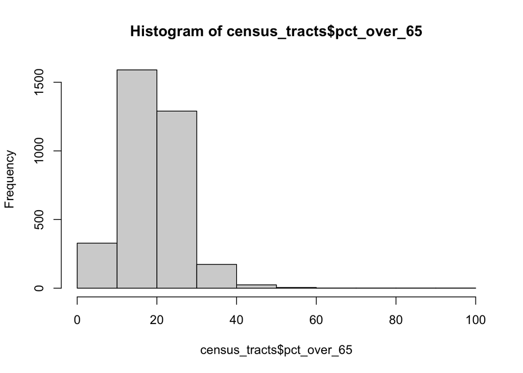

```r
hist(census_tracts$pct_over_65)
```

```r
summary(census_tracts$median_incomeE)
```

```
   Min. 1st Qu.  Median    Mean 3rd Qu.    Max.    NA's
  11558   55924   70188   77527   93286  250001      62
```

```r
vulnerable_tracts <- census_tracts %>%
  filter(median_incomeE < 56000,
         pct_over_65 > 23)

pct_vulnerable_tracts <- (nrow(vulnerable_tracts))/(nrow(census_tracts))*100
```

**Questions to answer:** - What income threshold did you choose and why? - What elderly population threshold did you choose and why? - How many tracts meet your vulnerability criteria? - What percentage of PA census tracts are considered vulnerable by your definition?

- The lower quantile value of the median income variable was around 56,000, indicating that any income below this amount is far enough away from the income earned by a larger share of the population and in this way represents a low income.
- The upper quantile value of the variable, pct_over_65, was a little over 23%, which indicates that the share of the population aged 65 and above is likely higher than usual when it reaches values of 23% or higher, therefore areas where the 65 and above population makes up more than 23% of the population should be given greater attention by being labeled as vulnerable.
- Almost 5% (4.88%) of tracts are categorized as vulnerable under the set thresholds.

#### Step 4: Calculate Distance to Hospitals

For each vulnerable tract, calculate the distance to the nearest hospital.

**Your Task:**

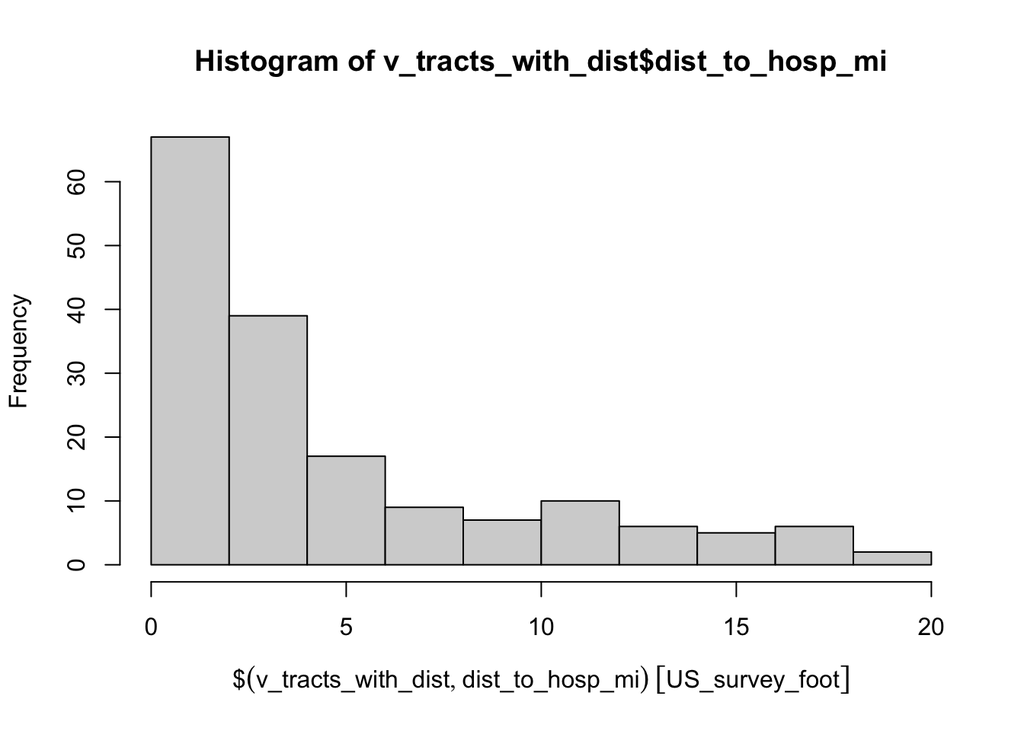

```r
# Transform to appropriate projected CRS
vulnerable_tracts_projected <- vulnerable_tracts %>%
  st_transform(crs = 3365)

hospitals_projected <- hospitals %>%
  st_transform(crs = 3365)

# Calculate distance from each tract centroid to nearest hospital

v_tracts_centroid <- st_centroid(vulnerable_tracts_projected)

  # turn all hospital points into one entity using union
hospitals_union <- st_union(hospitals_projected)

dist_matrix <- st_distance(v_tracts_centroid, hospitals_union)

v_tracts_with_dist <- vulnerable_tracts_projected %>%
  mutate(dist_to_hosp_mi = dist_matrix/5280) # conversion factor from ft to miles

hist(v_tracts_with_dist$dist_to_hosp_mi)
```

```r
# Average distance to nearest hospital for vulnerable tracts
v_tracts_avg_dist <- mean(v_tracts_with_dist$dist_to_hosp_mi)

# Maximum distance
v_tracts_max_dist <- max(v_tracts_with_dist$dist_to_hosp_mi)

# Tracts with distance to hospital exceeding 15 miles
v_tracts_with_dist %>% filter(as.numeric(dist_to_hosp_mi) > 15) %>%
  nrow()
```

```
[1] 9
```

**Requirements:** - Use an appropriate projected coordinate system for Pennsylvania - Calculate distances in miles - Explain why you chose your projection

**Questions to answer:** - What is the average distance to the nearest hospital for vulnerable tracts? - What is the maximum distance? - How many vulnerable tracts are more than 15 miles from the nearest hospital?

- The average distance to the nearest hospital for vulnerable tracts is 4.71 miles.
- The greatest distance a vulnerable tract is from the nearest hospital is about 19.16 miles.
- There are 9 tracts whose nearest hospitals are more than 15 miles away.

#### Step 5: Identify Underserved Areas

Define “underserved” as vulnerable tracts that are more than 15 miles from the nearest hospital.

**Your Task:**

```r
# Create underserved variable
v_tracts_with_dist <- v_tracts_with_dist %>%
  mutate(underserved = case_when(
           as.numeric(dist_to_hosp_mi) <= 15 ~ "Not Underserved",
           as.numeric(dist_to_hosp_mi) > 15 ~ "Underserved"
         ))
v_tracts_with_dist %>%
  filter(underserved == "Underserved") %>%
  nrow() # total tracts "Underserved"
```

```
[1] 9
```

```r
v_tracts_with_dist %>%
  summarise(
    n_underserved = sum(underserved == "Underserved", na.rm = TRUE),
    pct_underserved = n_underserved / n() * 100
  ) # percent of total tracts that are "Underserved"
```

```
Simple feature collection with 1 feature and 2 fields
Geometry type: MULTIPOLYGON
Dimension:     XY
Bounding box:  xmin: 1204220 ymin: 145044.8 xmax: 2736008 ymax: 1028009
Projected CRS: NAD83(HARN) / Pennsylvania South (ftUS)
  n_underserved pct_underserved                       geometry
1             9        5.357143 MULTIPOLYGON (((1366015 303...
```

**Questions to answer:** - How many tracts are underserved? - What percentage of vulnerable tracts are underserved? - Does this surprise you? Why or why not?

#### Step 6: Aggregate to County Level

Use spatial joins and aggregation to calculate county-level statistics about vulnerable populations and hospital access.

**Your Task:**

```r
# Spatial join tracts to counties

  #match projection of tracts to counties
pa_counties_projected <- pa_counties %>%
  st_transform(crs = 3365)
st_crs(pa_counties_projected) == st_crs(v_tracts_with_dist) #TRUE
```

```
[1] TRUE
```

```r
  #spatial join for vulnerable tracts- each tract gets county attributes
v_tracts_joined <- v_tracts_with_dist %>%
  st_join(pa_counties_projected, largest = TRUE)

# Aggregate statistics by county
county_summaries <- v_tracts_joined %>%
  st_drop_geometry() %>%
  group_by(COUNTY_NAM) %>%
  summarise(
    n_tracts = n(),
    n_underserved = sum(underserved == "Underserved", na.rm = TRUE),
    pct_underserved = n_underserved / n_tracts * 100,
    total_over_65 = sum(over_65, na.rm = TRUE),
    total_pop = sum(total_popE, na.rm = TRUE),
    total_underserved = sum(total_over_65[underserved == "Underserved"], na.rm = TRUE),
    mean_dist_mi = mean(as.numeric(dist_to_hosp_mi), na.rm = TRUE),
    .groups = "drop"
  )

# top 5 counties with highest pct of underserved tracts
county_summaries %>%
  arrange(desc(pct_underserved)) %>%
  slice(1:5)
```

```
# A tibble: 5 × 8
  COUNTY_NAM n_tracts n_underserved pct_underserved total_over_65 total_pop
  <chr>         <int>         <int>           <dbl>         <dbl>     <dbl>
1 BRADFORD          1             1             100          1545      5466
2 FOREST            1             1             100           802      2701
3 JUNIATA           1             1             100           492      1782
4 MONROE            1             1             100           314      1299
5 SULLIVAN          1             1             100           282       918
# ℹ 2 more variables: total_underserved <dbl>, mean_dist_mi <dbl>
```

```r
# counties with most vulnerable people living far from hospitals
county_summaries %>%
  arrange(desc(total_underserved)) %>%
  slice(1:5)
```

```
# A tibble: 5 × 8
  COUNTY_NAM n_tracts n_underserved pct_underserved total_over_65 total_pop
  <chr>         <int>         <int>           <dbl>         <dbl>     <dbl>
1 DAUPHIN           2             1              50          2122      8410
2 BRADFORD          1             1             100          1545      5466
3 FOREST            1             1             100           802      2701
4 JUNIATA           1             1             100           492      1782
5 MONROE            1             1             100           314      1299
# ℹ 2 more variables: total_underserved <dbl>, mean_dist_mi <dbl>
```

**Required county-level statistics:** - Number of vulnerable tracts - Number of underserved tracts  
- Percentage of vulnerable tracts that are underserved - Average distance to nearest hospital for vulnerable tracts - Total vulnerable population

**Questions to answer:** - Which 5 counties have the highest percentage of underserved vulnerable tracts? - Which counties have the most vulnerable people living far from hospitals? - Are there any patterns in where underserved counties are located?

- The 5 counties with the highest percentage of underserved vulnerable tracts are Bradford, Forest, Juniata, Monroe, and Sullivan counties - where 100% of each county’s tracts are underserved (all counties consist of only one tract).
- Dauphin, Bradford, Forest, Juniata and Monroe counties have the greatest total counts of vulnerable people living far from hospitals, starting at 2,122 people.
- Looking more closely at each county in PA, there appears to be a potential pattern of clustering of underserved counties in eastern central parts of the state, while others like that of Monroe county are to the far east, Bradford and Sullivan counties are at the north eastern border and Forest county in the far west. The commonalities between most of these counties is that they are largely rural, low-density areas, which may offer some explanation for why hospitals are not always in close proximity.

#### Step 7: Create Summary Table

Create a professional table showing the top 10 priority counties for healthcare investment.

**Your Task:**

```r
# Create and format priority counties table

county_summaries %>%
  arrange(desc(pct_underserved)) %>%
  slice(1:10) %>%
  mutate(
    pct_underserved = round(pct_underserved, 1),
    mean_dist_mi = round(mean_dist_mi, 1),
    total_pop = comma(total_pop),
    total_over_65 = comma(total_over_65),
    total_underserved = comma(total_underserved)) %>%
  select(
    "County" = COUNTY_NAM,
    "Total Vulnerable Tracts" = n_tracts,
    "Underserved Tracts" = n_underserved,
    "% Vulnerable Tracts Underserved" = pct_underserved,
    "Total Population" = total_pop,
    "Total 65+ Population" = total_over_65,
    "Total 65+ Living >15 mi from Hospital" = total_underserved,
    "Mean Distance to Hospital (mi)" = mean_dist_mi
  ) %>%
  kable(
      caption = "Top 10 Priority Counties for Healthcare Investment",

      format.args = list(big.mark = ',')) %>%
  kable_styling(
    bootstrap_options = c("striped", "hover", "condensed", "responsive"),
    full_width = FALSE
  ) %>%
  footnote(
    general = c("Underserved Criteria (calculated at the tract-level):",
                "1. More than 23% of the population are 65+",
                "2. Median income is <$56,000",
                "3. The nearest hospital is 15 or more miles away on average",
                "Source: American Community Survey 2018-2022 5-Year Estimates"),
    general_title = "Notes:"
  ) %>%
  row_spec(0, bold = TRUE)
```

Top 10 Priority Counties for Healthcare Investment

| County | Total Vulnerable Tracts | Underserved Tracts | % Vulnerable Tracts Underserved | Total Population | Total 65+ Population | Total 65+ Living >15 mi from Hospital | Mean Distance to Hospital (mi) |
| --- | --- | --- | --- | --- | --- | --- | --- |
| BRADFORD | 1 | 1 | 100.0 | 5,466 | 1,545 | 1,545 | 16.7 |
| FOREST | 1 | 1 | 100.0 | 2,701 | 802 | 802 | 18.1 |
| JUNIATA | 1 | 1 | 100.0 | 1,782 | 492 | 492 | 15.9 |
| MONROE | 1 | 1 | 100.0 | 1,299 | 314 | 314 | 17.7 |
| SULLIVAN | 1 | 1 | 100.0 | 918 | 282 | 282 | 16.9 |
| DAUPHIN | 2 | 1 | 50.0 | 8,410 | 2,122 | 2,122 | 9.9 |
| POTTER | 3 | 1 | 33.3 | 9,062 | 2,376 | 0 | 9.6 |
| CLEARFIELD | 4 | 1 | 25.0 | 13,056 | 3,525 | 0 | 11.4 |
| CRAWFORD | 4 | 1 | 25.0 | 9,072 | 2,516 | 0 | 8.4 |
| ALLEGHENY | 22 | 0 | 0.0 | 51,790 | 13,896 | 0 | 2.8 |

Notes:  
Underserved Criteria (calculated at the tract-level):  
1. More than 23% of the population are 65+  
2. Median income is <$56,000  
3. The nearest hospital is 15 or more miles away on average  
Source: American Community Survey 2018-2022 5-Year Estimates

**Requirements:** - Use `knitr::kable()` or similar for formatting - Include descriptive column names - Format numbers appropriately (commas for population, percentages, etc.) - Add an informative caption - Sort by priority (you decide the metric)

## Part 2: Comprehensive Visualization

Using the skills from Week 3 (Data Visualization), create publication-quality maps and charts.

### Map 1: County-Level Choropleth

Create a choropleth map showing healthcare access challenges at the county level.

**Your Task:**

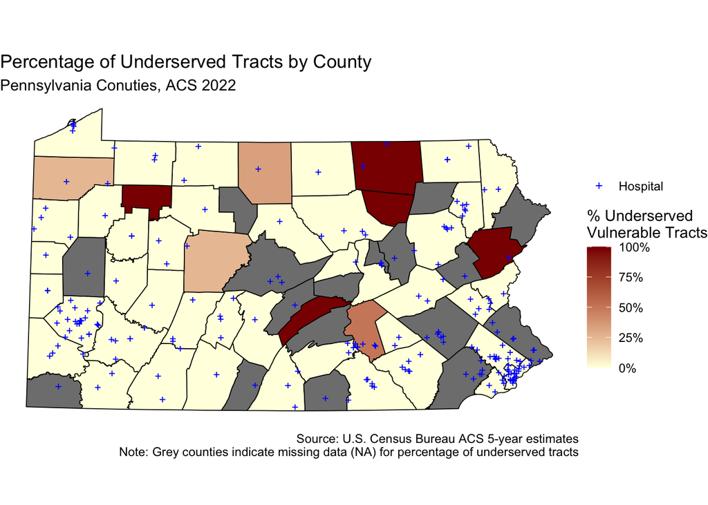

```r
# Create county-level access map

healthcare_access_map <- pa_counties_projected %>%
  full_join(county_summaries, by = "COUNTY_NAM") %>%
  ggplot() +
  geom_sf(aes(fill = pct_underserved), color = "black", linewidth = 0.3) +
  geom_sf(data = hospitals_projected, aes(color = "Hospital"), size = 1, shape = 3) +
  scale_fill_gradient(
    low = "lightyellow",
    high = "darkred",
    name = "% Underserved \nVulnerable Tracts",
    labels = scales::label_percent(scale = 1, accuracy = 1)
  ) +
  scale_color_manual(
    name = "",
    values = c("Hospital" = "blue")) +
  labs(
    title = "Percentage of Underserved Tracts by County",
    subtitle = "Pennsylvania Conuties, ACS 2022",
    caption = "Source: U.S. Census Bureau ACS 5-year estimates\nNote: Grey counties indicate missing data (NA) for percentage of underserved tracts"
  ) +
  theme_void()

healthcare_access_map
```

**Requirements:** - Fill counties by percentage of vulnerable tracts that are underserved - Include hospital locations as points - Use an appropriate color scheme - Include clear title, subtitle, and caption - Use `theme_void()` or similar clean theme - Add a legend with formatted labels

### Map 2: Detailed Vulnerability Map

Create a map highlighting underserved vulnerable tracts.

**Your Task:**

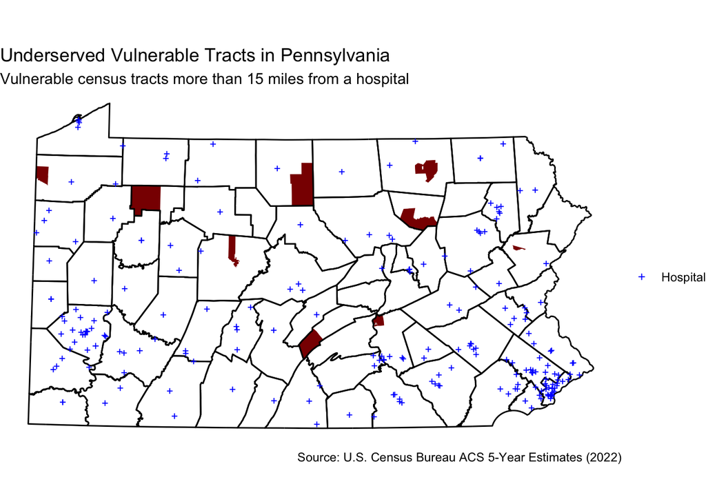

```r
# Create detailed tract-level map

ggplot() +
  geom_sf(data = v_tracts_joined %>% filter(underserved == "Underserved"), # underserved in contrasting color
          fill = "darkred", color = NA) +
  geom_sf(data = pa_counties_projected, fill = NA, color = "black", linewidth = 0.5) + #county boundaries (just borders)
  geom_sf(data = hospitals_projected, aes(color = "Hospital"), size = 1, shape = 3) + #hospital points
  scale_color_manual(
    name = "",
    values = c("Hospital" = "blue")
  ) +
  labs(
    title = "Underserved Vulnerable Tracts in Pennsylvania",
    subtitle = "Vulnerable census tracts more than 15 miles from a hospital",
    caption = "Source: U.S. Census Bureau ACS 5-Year Estimates (2022)"
  ) +
  theme_void()
```

**Requirements:** - Show underserved vulnerable tracts in a contrasting color - Include county boundaries for context - Show hospital locations - Use appropriate visual hierarchy (what should stand out?) - Include informative title and subtitle

### Chart: Distribution Analysis

Create a visualization showing the distribution of distances to hospitals for vulnerable populations.

**Your Task:**

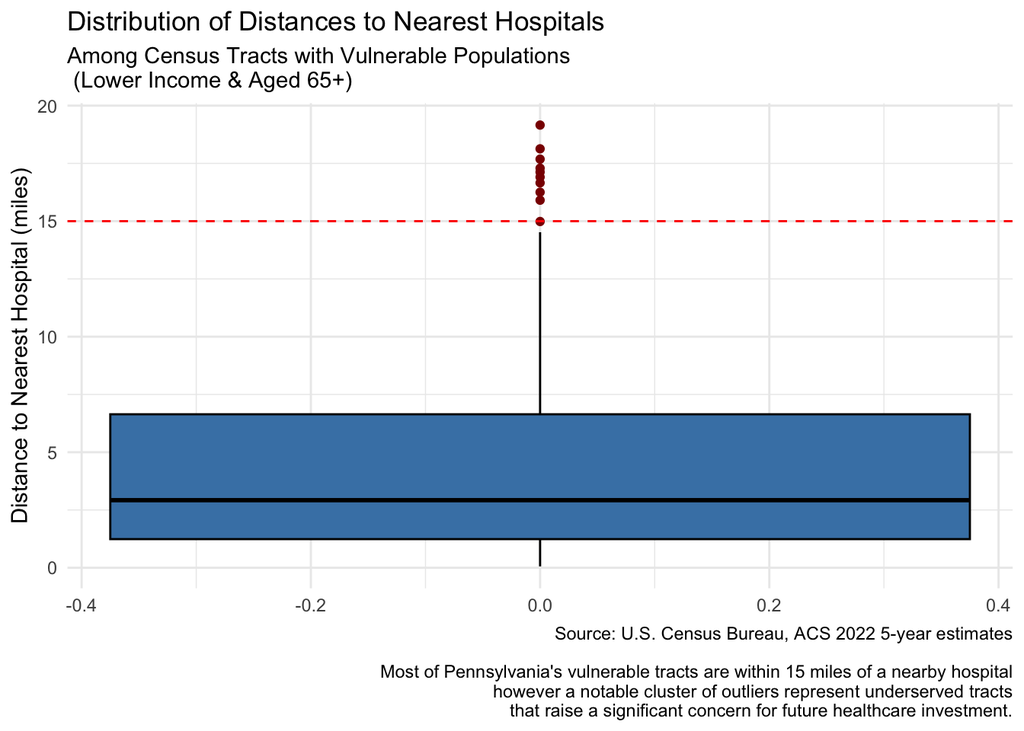

```r
# Create distribution visualization

ggplot(v_tracts_with_dist, aes(y = as.numeric(dist_to_hosp_mi))) +
  geom_boxplot(fill = "steelblue", color = "black",outlier.colour = "darkred") +
  labs(
    title = "Distribution of Distances to Nearest Hospitals",
    subtitle = "Among Census Tracts with Vulnerable Populations\n (Lower Income & Aged 65+)",
    y = "Distance to Nearest Hospital (miles)",
    caption = "Source: U.S. Census Bureau, ACS 2022 5-year estimates\n\n Most of Pennsylvania's vulnerable tracts are within 15 miles of a nearby hospital\n however a notable cluster of outliers represent underserved tracts\n that raise a significant concern for future healthcare investment."
  ) +
  geom_hline(yintercept = 15, linetype = "dashed", color = "red") +
  theme_minimal()
```

**Suggested chart types:** - Histogram or density plot of distances - Box plot comparing distances across regions - Bar chart of underserved tracts by county - Scatter plot of distance vs. vulnerable population size

**Requirements:** - Clear axes labels with units - Appropriate title - Professional formatting - Brief interpretation (1-2 sentences as a caption or in text)

## Part 3: Bring Your Own Data Analysis

Choose your own additional spatial dataset and conduct a supplementary analysis.

### Challenge Options

Choose ONE of the following challenge exercises, or propose your own research question using OpenDataPhilly data (https://opendataphilly.org/datasets/).

**Note these are just loose suggestions to spark ideas - follow or make your own as the data permits and as your ideas evolve. This analysis should include bringing in your own dataset, ensuring the projection/CRS of your layers align and are appropriate for the analysis (not lat/long or geodetic coordinate systems). The analysis portion should include some combination of spatial and attribute operations to answer a relatively straightforward question**

#### Education & Youth Services

**Option A: Educational Desert Analysis** - **Data:** Schools, Libraries, Recreation Centers, Census tracts (child population) - **Question:** “Which neighborhoods lack adequate educational infrastructure for children?” - **Operations:** Buffer schools/libraries (0.5 mile walking distance), identify coverage gaps, overlay with child population density - **Policy relevance:** School district planning, library placement, after-school program siting

**Option B: School Safety Zones** - **Data:** Schools, Crime Incidents, Bike Network - **Question:** “Are school zones safe for walking/biking, or are they crime hotspots?” - **Operations:** Buffer schools (1000ft safety zone), spatial join with crime incidents, assess bike infrastructure coverage - **Policy relevance:** Safe Routes to School programs, crossing guard placement

#### Environmental Justice

**Option C: Green Space Equity** - **Data:** Parks, Street Trees, Census tracts (race/income demographics) - **Question:** “Do low-income and minority neighborhoods have equitable access to green space?” - **Operations:** Buffer parks (10-minute walk = 0.5 mile), calculate tree canopy or park acreage per capita, compare by demographics - **Policy relevance:** Climate resilience, environmental justice, urban forestry investment —

#### Public Safety & Justice

**Option D: Crime & Community Resources** - **Data:** Crime Incidents, Recreation Centers, Libraries, Street Lights - **Question:** “Are high-crime areas underserved by community resources?” - **Operations:** Aggregate crime counts to census tracts or neighborhoods, count community resources per area, spatial correlation analysis - **Policy relevance:** Community investment, violence prevention strategies —

#### Infrastructure & Services

**Option E: Polling Place Accessibility** - **Data:** Polling Places, SEPTA stops, Census tracts (elderly population, disability rates) - **Question:** “Are polling places accessible for elderly and disabled voters?” - **Operations:** Buffer polling places and transit stops, identify vulnerable populations, find areas lacking access - **Policy relevance:** Voting rights, election infrastructure, ADA compliance

#### Health & Wellness

**Option F: Recreation & Population Health** - **Data:** Recreation Centers, Playgrounds, Parks, Census tracts (demographics) - **Question:** “Is lack of recreation access associated with vulnerable populations?” - **Operations:** Calculate recreation facilities per capita by neighborhood, buffer facilities for walking access, overlay with demographic indicators - **Policy relevance:** Public health investment, recreation programming, obesity prevention

#### Emergency Services

**Option G: EMS Response Coverage** - **Data:** Fire Stations, EMS stations, Population density, High-rise buildings - **Question:** “Are population-dense areas adequately covered by emergency services?” - **Operations:** Create service area buffers (5-minute drive = ~2 miles), assess population coverage, identify gaps in high-density areas - **Policy relevance:** Emergency preparedness, station siting decisions

#### Arts & Culture

**Option H: Cultural Asset Distribution** - **Data:** Public Art, Museums, Historic sites/markers, Neighborhoods - **Question:** “Do all neighborhoods have equitable access to cultural amenities?” - **Operations:** Count cultural assets per neighborhood, normalize by population, compare distribution across demographic groups - **Policy relevance:** Cultural equity, tourism, quality of life, neighborhood identity

### Data Sources

**OpenDataPhilly:** https://opendataphilly.org/datasets/ - Most datasets available as GeoJSON, Shapefile, or CSV with coordinates - Always check the Metadata for a data dictionary of the fields.

**Additional Sources:** - **Pennsylvania Open Data:** https://data.pa.gov/ - **Census Bureau (via tidycensus):** Demographics, economic indicators, commute patterns - **TIGER/Line (via tigris):** Geographic boundaries

### Recommended Starting Points

**If you’re feeling confident:** Choose an advanced challenge with multiple data layers. **If you are a beginner, choose something more manageable that helps you understand the basics**

**If you have a different idea:** Propose your own question! Just make sure: - You can access the spatial data - You can perform at least 2 spatial operations

### Your Analysis

**Your Task:**

1. **Find and load additional data**
   - Document your data source
   - Check and standardize the CRS
   - Provide basic summary statistics

```r
# Load your additional dataset - Option E

# Polling Place Accsessibility - census data

vars_b18101 <- load_variables(2022, "acs5") %>%
  filter(str_detect(name, "B18101"))

disability_vars <- c(
  male_dis1 ="B18101_004",
  male_dis2 = "B18101_007",
  male_dis3 = "B18101_010",
  male_dis4 = "B18101_013", #male with disability
  male_dis5 = "B18101_016",
  male_dis6 = "B18101_019", #males 65 plus with disability
  fem_dis1 = "B18101_023",
  fem_dis2 = "B18101_026",
  fem_dis3 = "B18101_029",
  fem_dis4 = "B18101_032", #female with disability
  fem_dis5 = "B18101_035",
  fem_dis6 = "B18101_038" #female 65 plus with disability
)

disability_tract_data <- get_acs(
  geography = "tract",
  variables = disability_vars,
  year = 2022,
  output = "wide",
  state = "PA"
)
disability_tract_data <- disability_tract_data %>% #add new disability variables
  mutate(
    totpop_disabled = (male_dis1E + male_dis2E + male_dis3E + male_dis4E + male_dis5E + male_dis6E +
      fem_dis1E + fem_dis2E + fem_dis3E + fem_dis4E + fem_dis5E + fem_dis6E),
    over65_disabled = male_dis5E + male_dis6E + fem_dis5E + fem_dis6E)
        #later, may also add percent disabled and percent over 65 disabled variables

optionE_data <- disability_tract_data %>% #join disability data to other tract with age, total population and median income data
  left_join(census_tracts, by = "GEOID")


#Geographic data - need: Philadelphia county, already have: census tracts
phil_county <- pa_counties %>%
  filter(COUNTY_NAM == "PHILADELPHIA")

philly_tracts <- tracts(
  state = "PA",
  county = "Philadelphia",
  year = 2022)
#Polling data
polling_places <- st_read("data/polling_places/polling_places.shp")
#Transform to same coordinate projections
phil_county <- phil_county %>%
  st_transform(crs = 5070) # Albers Equal Area

philly_tracts <- philly_tracts %>%
  st_transform(st_crs(phil_county))

polling_places <- polling_places %>%
  st_transform(st_crs(phil_county))
```

**Questions to answer:** - What dataset did you choose and why? - What is the data source and date? - How many features does it contain? - What CRS is it in? Did you need to transform it?

Write a clear research statement that your analysis will answer.

**Examples:** - “Do vulnerable tracts have adequate public transit access to hospitals?” - “Are EMS stations appropriately located near vulnerable populations?” - “Do areas with low vehicle access have worse hospital access?”

- Are polling places accessible for elderly and disabled voters?
3. **Conduct spatial analysis**

Use at least TWO spatial operations to answer your research question.

**Required operations (choose 2+):** - Buffers - Spatial joins - Spatial filtering with predicates - Distance calculations - Intersections or unions - Point-in-polygon aggregation

**Your Task:**

```r
# Your spatial analysis

# high interest tracts - those with high shares of vulnerable groups characterized by large populations of elderly and people with disabilties

optionE_data <- optionE_data %>%
  mutate(pct_w_disability = totpop_disabled/total_popE *100) # adding new variable: % of pop. with disability

# filter only Philadelphia tracts - study area
optionE_data <- optionE_data %>%
  filter(str_detect(NAME, "Philadelphia"))

# define threshold of vulnerability: % with disability
optionE_data %>%
  pull(pct_w_disability) %>%
  summary() # threshold: > 20% (approximate upper quantile value)
```

```
   Min. 1st Qu.  Median    Mean 3rd Qu.    Max.    NA's
   0.00   10.84   15.61   16.43   20.76   48.00      17
```

```r
# define threshold of vulnerability: % over 65
optionE_data %>%
  pull(pct_over_65) %>%
  summary() # threshold: > 20% (approximate upper quantile value)
```

```
   Min. 1st Qu.  Median    Mean 3rd Qu.    Max.    NA's
  0.000   8.865  13.246  14.559  19.210  76.543      17
```

```r
# create 'vulnerable' variable
optionE_data <- optionE_data %>%
  mutate(vulnerable = pct_over_65 > 20 | pct_w_disability > 20) # tract is vulnerable if it has a high share of people over 65 or people with disabilities
# what percentage of tracts are vulnerable?
optionE_data %>%
  summarise(
    n_vulnerable = sum(vulnerable, na.rm = TRUE),
    n_total = n(),
    pct_vulnerable = n_vulnerable / n_total * 100 # 39.46%
  )
```

```
# A tibble: 1 × 3
  n_vulnerable n_total pct_vulnerable
         <int>   <int>          <dbl>
1          161     408           39.5
```

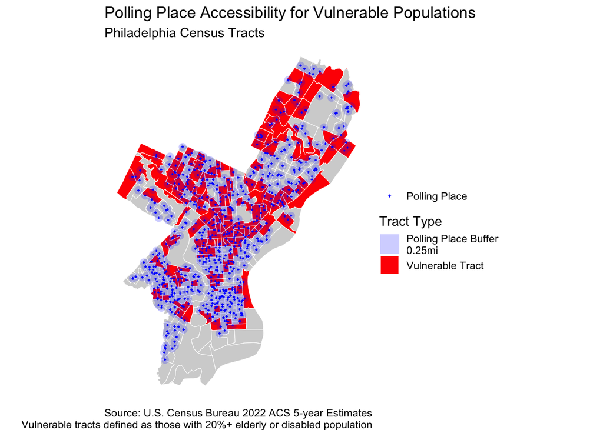

```r
# Polling places analysis

# Create walking distance buffer around each polling place
polling_buffer <- st_buffer(polling_places, dist = 400) # 400m = ~0.25mi, good walking distance
polling_coverage <- st_union(polling_buffer)

# Find which tracts intersect with polling coverage area
  # join tract data to geometry data

optionE_data <- optionE_data %>%
  select(GEOID, NAME, totpop_disabled, over65_disabled, total_popE, pct_over_65, pct_w_disability, vulnerable) # reducing total variables in dataframe
optionE_data <- optionE_data %>%
  left_join(philly_tracts, by = "GEOID") # adding back geometry by joining with philly tracts
optionE_data <- st_as_sf(optionE_data) # setting dataframe with sf class

# intersection
intersecting_tracts <- st_intersects(optionE_data, polling_coverage)
# create new variable 'near_polling'
optionE_data <- optionE_data %>%
  mutate(near_polling = lengths(intersecting_tracts) > 0) # lengths counts how many buffer zones the tract intersects with, if > 0, tract is close to polling place

# Find vulnerable tracts that do NOT intersect with the buffer, create new variable 'priority'
optionE_data <- optionE_data %>%
  mutate(priority = vulnerable == TRUE & near_polling == FALSE) # a 'priority' tract is one where it is both vulnerable and not near polling

# Mapping results
ggplot() +
  geom_sf(data = optionE_data, fill = "lightgrey", color = "white") +
  geom_sf(data = optionE_data %>% filter(vulnerable == TRUE),
          aes( fill = "Vulnerable Tract"), color = "white") +
  geom_sf(data = polling_coverage, aes(fill = "Polling Place Buffer\n0.25mi"), alpha = 0.2, color = NA) +
  geom_sf(data = polling_places, aes(color = "Polling Place"), size = 0.3, shape = 3) +
  scale_fill_manual(
    name = "Tract Type",
    values = c(
      "Vulnerable Tract" = "red",
      "Polling Place Buffer\n0.25mi" = "blue")
  ) +
  scale_color_manual(
    name = "",
    values = c("Polling Place" = "blue")
  ) +
  labs(
    title = "Polling Place Accessibility for Vulnerable Populations",
    subtitle = "Philadelphia Census Tracts",
    caption = "Source: U.S. Census Bureau 2022 ACS 5-year Estimates\nVulnerable tracts defined as those with 20%+ elderly or disabled population",
  ) +
  theme_void()
```

**Your interpretation:**

This analysis was conducted to find where, if any place, vulnerable populations experience low access to polling places in Philadelphia. After defining a vulnerable tract as one where either the percentage of those over 65 or those with a disability exceeded 20%, the analysis found that almost 40% of tracts are flagged as vulnerable. I created a buffer around each polling place of about 0.25 miles (a walkable distance) to see whether the populations in the identified vulnerable tracts could easily walk to a polling place or not. The resulting map visualization of both vulnerable tracts and the buffered polling places demonstrates that the vulnerable populations of interest have adequate access to polling places. As a result, there may not be an urgent need for greater investment in boosting polling place infrastructure for the identified populations.

## Finally - A few comments about your incorporation of feedback!

Take a few moments to clean up your markdown document and then write a line or two or three about how you may have incorporated feedback that you recieved after your first assignment.

- I have avoided using head() or print () directly in my quarto document, and instead use these commands in the console for my own reference.
- I have hidden the setup code using echo = FALSE

## Submission Requirements

**What to submit:**

1. **Rendered HTML document posted to your course portfolio** with all code, outputs, maps, and text
   - Use `embed-resources: true` in YAML so it’s a single file
   - All code should run without errors
   - All maps and charts should display correctly
2. Submit the correct and working links of your assignment on Canvas